# Eating Habits Observation Log

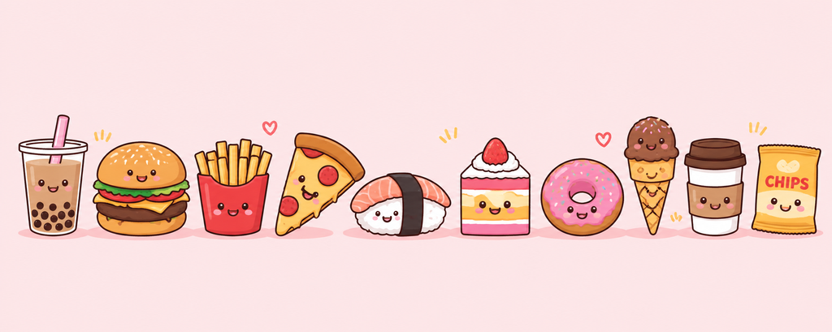

## About data

This data is collected from current student from University of Auckland, aiming to explore their eating habits.The observational log also includes an observation of most common purchased food in campus supermarket - Munchy Mart.The dataset includes variables for background information such as gender, age_group, current status(employee, student or other); variables associated with the topic such as ,type of food they eat, number of meals they have per day, most substantial meal, whether have meal on time, description of overall health, and Google Form submission timestamps.Additional variable food category is added since we are interested in the most popular lunch food choice in Munchy Mart.

In this report, we focus more on using R-generated plots to visualise the relationships and underlying patterns between different variables, including the lunch purchasing behaviour at Munchy Mart.

## plot1: Meal frequency by student status

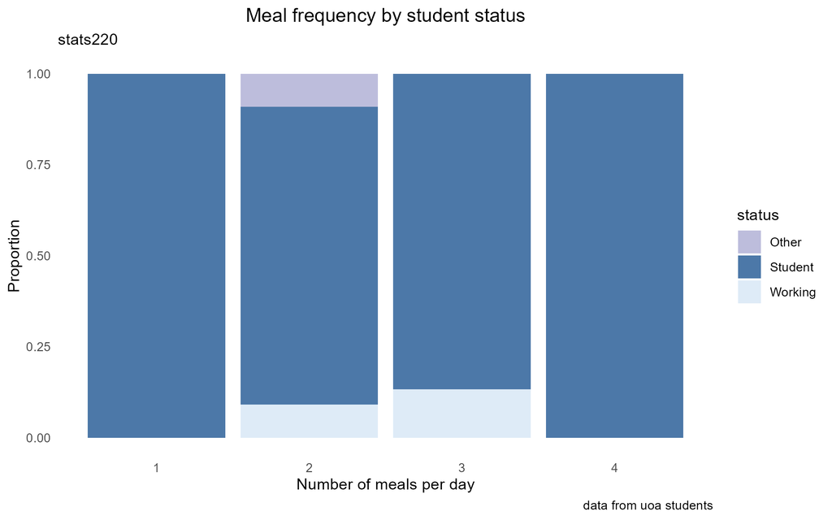

Stacked bar chart comparing student and working participants by number of meals they have per day

## plot2: Most commonly purchased lunch food types

This chart summarises the most commonly observed lunch food purchases at Munchy Mart. Meal-type food appeared more frequently than drink-only or bakery items. This is reasonable because people are more likely to purchase full meal-type foods during regular lunch hours, when they are looking for a more substantial meal rather than just snacks or drinks.

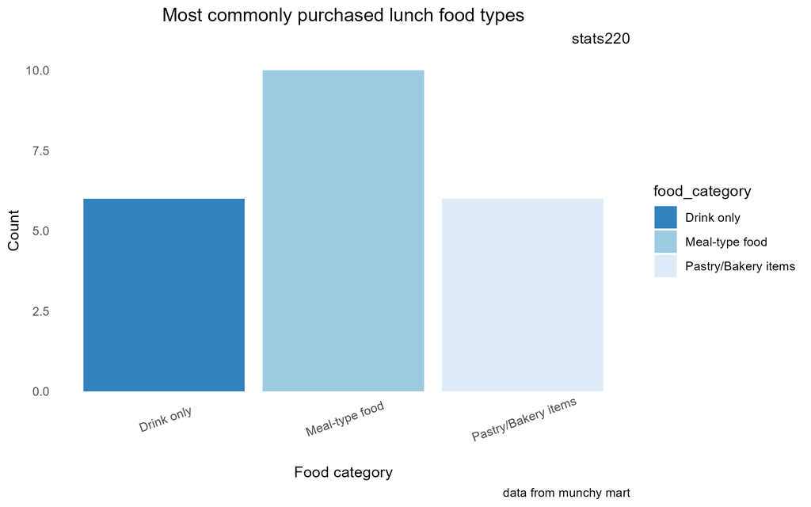

Bar chart showing meal-type food was the most commonly purchased lunch category at Munchy Mart

## plot3: When observations were recorded

This histogram shows the distribution of Google Form submission times throughout the day. The timestamps represent when observations were recorded rather than actual meal consumption times.From the histogram, we can clearly see that most participants submitted responses at night, particularly after 8 pm. This is likely because the Google Form was finalised and shared around that time, so many participants responded immediately after receiving it. In addition, since most participants were my classmates, the time after dinner was generally their free time, making it more convenient for them to complete the survey.

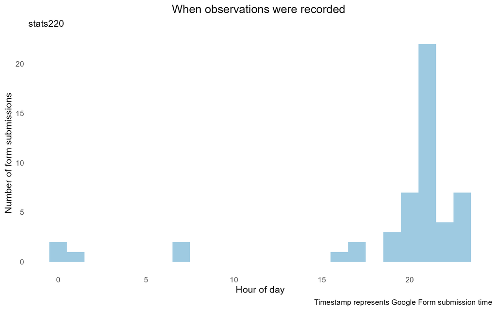

Histogram showing the distribution of Google Form submission times throughout the day